# Brualdi's Conjecture — a from-scratch tutorial

# Brualdi’s conjecture — a from-scratch tutorial

*A from-scratch, plain-language tour of Brualdi’s interchange-graph conjecture and its proof: starting from “what is a flip graph?” and building, patiently and with worked examples, up to “here is what was proved, how, and what is still on faith.” It assumes general mathematical comfort but treats this corner of combinatorics as new, defining every term the first time it appears and working small cases by hand. Phone-friendly: short chunks, matrices and pictures in monospace blocks, light notation. Read one part at a time.*

## Part 1 — Graphs, in 3 minutes

A **graph** is just a set of **vertices** (dots) and a set of **edges** (lines joining pairs of dots). That’s it. No directions, no repeated edges for us — a “simple graph.”

Two vertices joined by an edge are **adjacent** (or **neighbours**). The **degree** of a vertex is how many neighbours it has.

Tiny example — 4 vertices in a square:

```
A --- B
|     |
C --- D
```

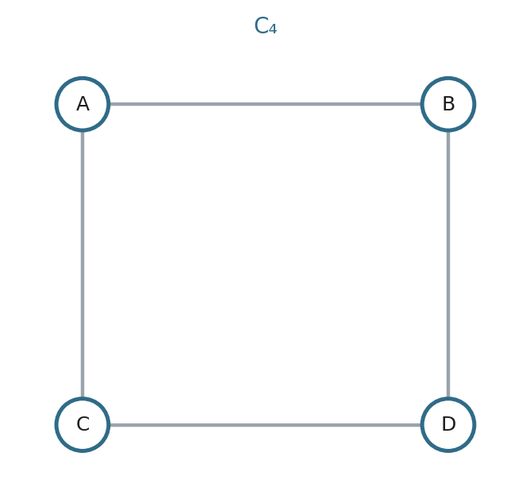

The 4-cycle C₄.

Vertices {A,B,C,D}; edges {AB, AC, BD, CD}. Every vertex has degree 2. This square graph has a name we’ll reuse: the **4-cycle**, written `C_4`.

That’s all the graph theory vocabulary we need to start. Everything in this project is an ordinary graph like this — the only twist is that our “dots” will turn out to be **matrices**.

## Part 2 — Walks, paths, cycles, and “Hamiltonian”

- A **walk** is a sequence of vertices, each adjacent to the next (you “walk” along edges).
- A **path** is a walk that never repeats a vertex.
- A **cycle** is a path that returns to its start (a closed loop), like A→B→D→C→A above.

Now the star concept:

- A graph is **Hamiltonian** if it has a cycle that visits **every** vertex exactly once (a *Hamilton cycle*). Named after Hamilton, who studied this on the dodecahedron.
- A **Hamilton path** is the path version: visits every vertex exactly once, but doesn’t have to return to start.

In `C_4` above, A→B→D→C→A is a Hamilton cycle, so `C_4` is Hamiltonian.

Why anyone cares: a Hamilton cycle is a way to list all the objects (vertices) so that consecutive ones differ by a single allowed “move.” That’s exactly a **combinatorial Gray code** — and that’s the broad family this whole problem lives in.

Deciding whether a *general* graph is Hamiltonian is famously hard (NP-complete). So proving an *entire infinite family* of graphs is always Hamiltonian is a real theorem, not a computation.

## Part 3 — Bipartite graphs and the colour rule

A graph is **bipartite** if you can colour every vertex black or white so that **every edge joins a black to a white** (no edge inside a colour class). The square `C_4` is bipartite: colour A,D black and B,C white — every edge is black–white.

Classic fact: **bipartite ⇔ no odd-length cycle.** (If you 2-colour along any cycle, the colours alternate, so the cycle must have even length.) Remember this — it comes back in Part 15, because for *our* special graphs something stronger is true.

One consequence we’ll lean on hard: in a bipartite graph, **any path alternates colours**. So a path with an even number of vertices starts and ends on *opposite* colours; odd number, *same* colour. This simple parity fact secretly drives the whole proof.

## Part 4 — The three Hamilton properties we care about

There’s a ladder of “how freely can you thread a single path through all vertices,” weakest first:

1. **Hamiltonian** — there exists *one* Hamilton cycle. (This is what Brualdi asked.)
2. **Hamilton-connected** — for *every* pair of vertices u, v there’s a Hamilton *path* from u to v. Far stronger: you may start and end anywhere.
3. **Hamilton-laceable** — the bipartite version of #2. In a bipartite graph you *cannot* have a Hamilton path between two **same-colour** vertices when the colour classes are equal-sized (parity from Part 3 forbids it). So the best possible is: a Hamilton path between *every* **opposite-colour** pair. A bipartite graph with that property is **laceable**.

We bundle the top of the ladder into one word:

> **Maximally Hamiltonian** = Hamilton-laceable if the graph is bipartite, Hamilton-connected if it isn’t. I.e. the strongest path property the graph is *allowed* to have.

### What these actually look like (small, checkable examples)

It’s worth seeing that “a Hamilton path between *every* pair” is real, not impossible. The trick: when your two endpoints happen to be neighbours, you may *not* hop directly between them (that would end the path immediately, skipping everyone) — so the path takes a scenic route. Hamilton- connectedness just says a scenic route always exists. (Every path below is real, machine-checked.)

**K₄ — the complete graph on 4 vertices (every pair joined).** (Notation: `K_n` is the **complete graph** on `n` vertices — every pair joined by an edge — so `K_2` is a single edge and `K_3` a triangle; and `K_{m,n}` is the **complete bipartite** graph, every one of `m` vertices on one side joined to every one of `n` on the other, e.g. `K_{3,3}`.) Total freedom: pick a start, pick an end, list the other two between them in any order — every step is automatically an edge.

```
0→1: 0-2-3-1     0→2: 0-1-3-2     0→3: 0-1-2-3
1→2: 1-0-3-2     1→3: 1-0-2-3     2→3: 2-0-1-3
```

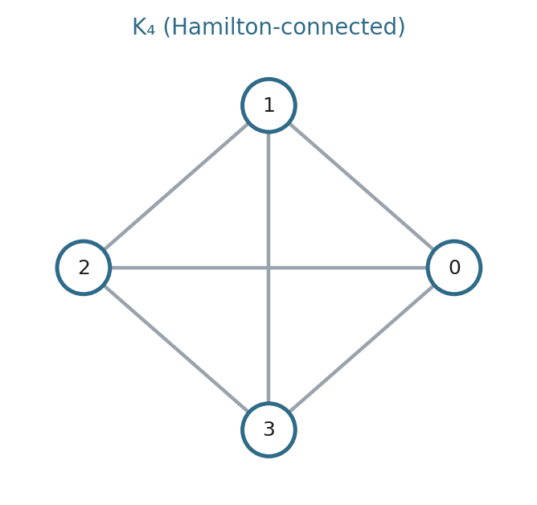

K₄: every pair joined, so any ordering of the vertices is a Hamilton path.

So with enough edges it’s clearly possible. But you don’t *need* a complete graph:

**The triangular prism — sparse, yet still Hamilton-connected.** Two triangles joined by three rungs; every vertex has only 3 neighbours (9 edges total):

```
top triangle:        0 — 1 — 2 — 0
bottom triangle:     3 — 4 — 5 — 3
rungs (a matching):  0–3,  1–4,  2–5
```

Watch the rerouting when the endpoints are adjacent (0 and 1 are neighbours, so the path can’t use edge 0–1):

```
0→1:  0-2-5-3-4-1      (skips the direct edge, snakes through all six)
0→3:  0-1-2-5-4-3
3→4:  3-5-2-0-1-4
```

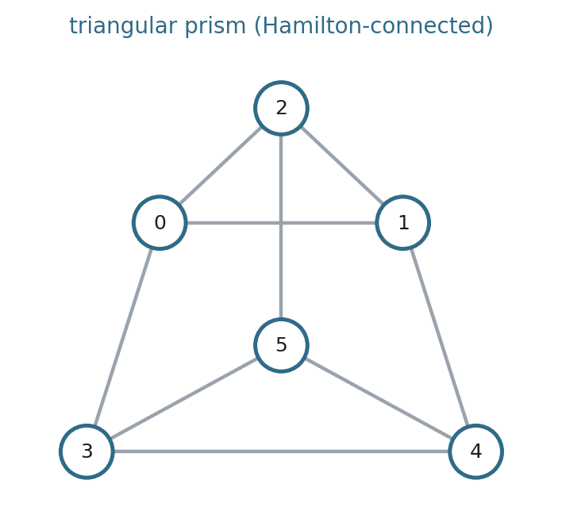

The triangular prism: only 3 neighbours per vertex, yet Hamilton-connected.

All 15 pairs work. The lesson: you need enough *alternative routes*, not completeness.

**Why bipartite graphs can only be “laceable.”** 2-colour a bipartite graph black/white so every edge is black–white. Any path then alternates colours, so a Hamilton path through all N vertices (N/2 of each colour) must start and end on *opposite* colours. A Hamilton path between two *same-colour* vertices is therefore impossible — pure parity, not a defect of the graph. The best a bipartite graph can manage is a Hamilton path between every *opposite-colour* pair: that’s **laceable**.

**K₃,₃ — complete bipartite, 3 + 3 (we meet it again later as CT₃).** Top a1,a2,a3; bottom b1,b2,b3; every top joined to every bottom:

```
opposite-colour (a Hamilton path exists):  a1→b1:  a1-b2-a2-b3-a3-b1
same-colour (impossible, by parity):       a1→a2:  none
```

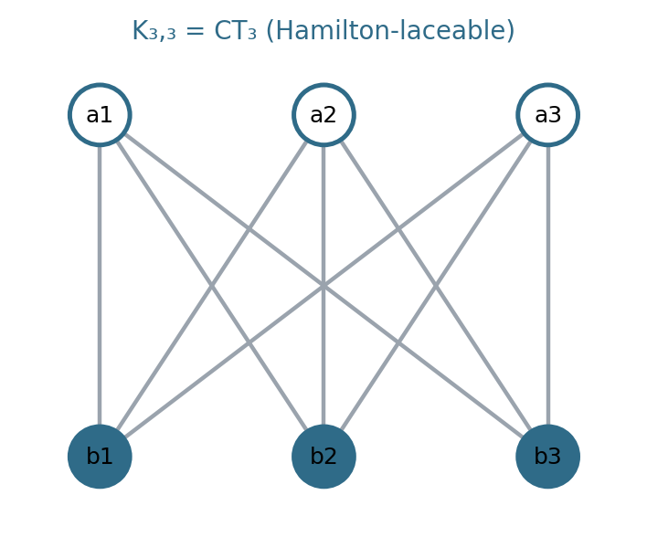

K₃,₃ = CT₃, drawn bipartite — the two colour classes are the rows.

**The cube Q₃ — 8 corners = 3-bit strings, edge = flip one bit** (a Hamilton path here is literally a Gray code):

```
000→111:  000-001-011-010-110-100-101-111   ✔ opposite parity
000→011:  none                               ✗ same parity (both even # of 1s)
```

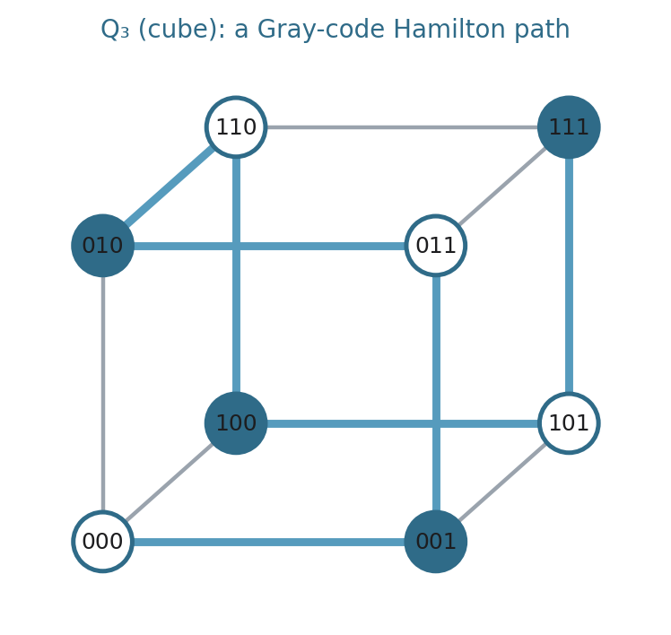

The cube Q₃: vertices 2-coloured by parity; a Gray-code Hamilton path highlighted in blue.

Both are laceable — every opposite-colour pair connects, no same-colour pair can.

Hold onto the distinction between “one cycle” (Hamiltonian) and “a path between every legal pair” (the strong versions). The jump between them is the whole game (Part 16 explains why we *want* the harder one).

## Part 5 — Flip graphs: the general idea

Here’s the unifying idea behind the whole subject.

Take some family of combinatorial objects (think: all ways to triangulate a polygon, all permutations, all standard Young tableaux, all binary strings…). Define a simple, local **“flip”** move that turns one object into another. Now build a graph:

- **vertices** = the objects,
- **edges** = pairs that differ by a single flip.

That graph is a **flip graph** (also called a “reconfiguration graph” or, when the flips are Markov-chain moves, a “state graph”). The associahedron (triangulation flips) and the permutohedron (adjacent-transposition flips) are famous examples.

Natural questions about a flip graph: Is it connected (can you always reach any object from any other by flips)? What’s its diameter? **Is it Hamiltonian** — can you list every object so consecutive ones differ by one flip (a Gray code)?

Our problem is exactly a flip-graph Hamiltonicity question, for one specific, important family of objects and one specific flip. Let’s meet them.

## Part 6 — Matrices with fixed margins (what “margins” means)

Our objects are **matrices of 0s and 1s with prescribed row sums and column sums.** First the word **margins**, because it’s central and it’s just jargon for something simple.

Take a matrix, add up each **row** and write those totals down the **right edge**; add up each **column** and write those totals along the **bottom edge**. Those edge totals are the **margins** (statisticians call them *marginal totals* — they literally sit in the margins of the table):

```
         c1 c2 c3  |  row sums  = R
   r1     1  0  1  |     2
   r2     0  1  1  |     2
   r3     1  1  0  |     2
         ---------
  col      2  2  2
  sums =  S
```

The “2 2 2” down the right is the **row-sum vector** `R = (2,2,2)`; the “2 2 2” along the bottom is the **column-sum vector** `S = (2,2,2)`. Together, R and S are *the margins* of the matrix.

Now fix the margins and gather every 0/1 matrix that has them:

- Fix a **row-sum vector** `R = (r_1, ..., r_m)` and a **column-sum vector** `S = (s_1, ..., s_n)`.
- `A(R,S)` = all `m×n` matrices of 0s and 1s whose row sums are exactly `R` and column sums exactly `S`. (The matrix above is *one* member of `A((2,2,2),(2,2,2))`; there are others with the same margins — e.g. shift the 1s around while keeping every row and column summing to 2.)

Where the idea comes from: a grid of counts with fixed row and column totals is a **contingency table** (statistics — e.g. a survey cross-tabulated by two attributes, with the attribute totals held fixed). The very same objects are **transportation plans** (ship from `m` sources with supplies `R` to `n` destinations with demands `S`) and **bipartite degree sequences** (Part 9). Brualdi’s question, in plain words: *can you walk through all tables with given margins, one small move at a time?*

Worked example we’ll reuse. Let `m = n = 3`, and `R = S = (1,1,1)` — every row and every column sums to 1. A 0/1 matrix with exactly one 1 per row and per column is a **permutation matrix**. There are `3! = 6` of them. Here are two:

```
1 0 0          0 1 0
0 1 0          1 0 0
0 0 1          0 0 1
```

The left is the identity. The right swaps rows’ 1s in columns 1 and 2. So `A((1,1,1),(1,1,1))` has 6 elements — the 6 permutation matrices of size 3.

For bigger or uneven margins the class `A(R,S)` is larger and far less symmetric — but it’s always the same idea: **fixed margins, 0/1 entries.**

## Part 7 — The 2×2 interchange move

Now the flip. A **2×2 interchange** (a.k.a. **swap** or **2-switch**) picks two rows and two columns where the 2×2 corner submatrix is one of these two patterns and flips it to the other:

```
1 0      <--->      0 1
0 1                 1 0
```

Everything outside those four cells stays fixed. Notice: each row of the little block keeps its sum (1 stays 1), and each column keeps its sum too. **So an interchange preserves all the margins** — it turns one matrix in `A(R,S)` into another matrix in the *same* `A(R,S)`.

Concrete example on a 3×3 matrix. Take the identity and interchange using rows {1,2}, columns {1,2}:

```
1 0 0          0 1 0
0 1 0    -->   1 0 0
0 0 1          0 0 1
```

The top-left 2×2 block went from `[[1,0],[0,1]]` to `[[0,1],[1,0]]`; row 3 / column 3 untouched. Both matrices have margins (1,1,1)/(1,1,1). One flip, one new matrix.

Foundational fact (**Ryser, 1957**): *any* two matrices in `A(R,S)` can be turned into each other by a sequence of these interchanges. In flip-graph language: the flip graph is **connected**. Good — connectivity is the floor; Brualdi conjectured the ceiling (Hamiltonicity).

## Part 8 — The interchange graph (our flip graph), by hand

Now assemble the flip graph for our objects + move:

> **Interchange graph `G(R,S)`**: vertices = the matrices in `A(R,S)`; an edge joins two matrices that differ by a single 2×2 interchange.

It’s an ordinary simple graph (Part 1). The fact that the dots are matrices is just labelling.

**Let’s build a tiny one fully.** Take `m=n=2`, `R=S=(1,1)`. Then `A` has just two matrices:

```
1 0          0 1
0 1          1 0
```

They differ by one interchange (the whole matrix is the 2×2 block). So `G` is two vertices joined by one edge — the single-edge graph `K_2`.

**Now the first interesting one: `R=S=(1,1,1)` (3×3 permutation matrices).** Six vertices (Part 6). Two permutation matrices are adjacent exactly when one is obtained from the other by **swapping two columns’ worth of 1s** — i.e. when the two permutations differ by one transposition (one swap).

- The identity `123` is adjacent to `213`, `132`, `321` (swap any one pair). Degree 3.
- Every permutation has exactly 3 single-swaps, so the graph is **3-regular** on 6 vertices.
- Colour each permutation by its **parity** (even/odd number of swaps to sort it). A single swap flips parity, so every edge joins an even to an odd permutation — the graph is **bipartite**, 3 of each colour.
- A 3-regular bipartite graph on 3+3 vertices, with every even adjacent to every odd… that’s exactly **`K_{3,3}`**, the complete bipartite graph.

So `G((1,1,1),(1,1,1)) = K_{3,3}`. **Keep this example in your pocket** — it’s the smallest rich case, and `K_{3,3}` will literally reappear as a building block (it’s “CT_3” in Part 12).

Sanity check you can do on the phone: `K_{3,3}` has a Hamilton cycle (e1→o1→e2→o2→e3→o3→e1, zig-zag across the colours). So this interchange graph is Hamiltonian — Brualdi’s conjecture holds for these margins. The conjecture says: *no matter the margins, you can always do this.*

## Part 9 — The same object in three other languages (optional)

*You can skip this part and lose nothing essential — it’s just three other ways people describe the exact same graph. But one of them may make it click, and the third may feel the most natural.*

**(1) A Markov-chain state graph.** To sample random contingency tables with fixed margins, statisticians start from one table and repeatedly apply random 2×2 interchanges — a random walk on the tables. `G(R,S)` is the “state graph” of that walk: states = tables, moves = interchanges.

**(2) The 1-skeleton of a transportation polytope.** Quick refresher: a **polytope** is the higher-dimensional analogue of a polygon (2D) or polyhedron (3D) — the solution set of some linear inequalities, with flat **faces**, straight **edges**, and corner **vertices**. Now relax our matrices: instead of 0/1 entries, allow any real entries **between 0 and 1** that still produce the **same margins** R and S (the capacity bounds 0 ≤ x_{ij} ≤ 1 are what force the corner vertices to be 0/1 matrices). That bounded set of real matrices forms a convex polytope — the **transportation polytope** (from the “transportation problem”: ship goods from sources with supplies R to destinations with demands S; the matrix says how much travels on each route). Two facts tie it back to us:

- its **corner vertices are exactly the 0/1 matrices** (the integer extreme points), and
- two corners are joined by an **edge of the polytope** precisely when they differ by **one 2×2 interchange**.

The **1-skeleton** of a polytope means: keep only its vertices and edges, throw away the 2-dimensional and higher faces — i.e. the plain graph of corners and edges. (Example: the 1-skeleton of an ordinary 3D cube is the 8-vertex “cube graph.”) So **`G(R,S)` is the 1-skeleton of the transportation polytope with margins R, S.** That’s the *only* sense in which anything “higher-dimensional” is involved: the polytope has higher faces, but the interchange graph itself is just corners and edges — an ordinary graph.

**(3) Bipartite graphs under 2-switches (the graph-theory view).** A **bipartite graph** splits its vertices into two sides, with edges only *between* the sides. Record one by a **biadjacency matrix**: rows = left-side vertices, columns = right-side vertices, and a `1` in cell (i,j) means “there is an edge from left-i to right-j” (0 = no edge). Then:

- the row sums and column sums are exactly the **degrees** (edge-counts) of the vertices on each side, so fixed margins = a fixed **degree sequence** on each side;
- a 2×2 interchange is exactly a **2-switch**: remove edges i–b and j–a, add edges i–a and j–b — the classic move that rewires a graph while keeping every vertex’s degree the same.

So `G(R,S)` is the **flip graph of all bipartite graphs with a prescribed degree sequence, under 2-switches** — what graph theorists call a **realization graph** of the degree sequence. For anyone working on graph Hamiltonicity, this is the dictionary that brings that intuition straight in.

Picture for #3 — a 2-switch on a little bipartite graph (left side 1,2; right side a,b):

```
 1 — a            1   a
        becomes      X
 2 — b            2   b      (edges 1a,2b  ->  1b,2a)
```

Same degrees on every vertex, different graph. That’s one edge of `G(R,S)`.

## Part 10 — Brualdi’s conjecture and its history

> **Brualdi’s conjecture (1980).** For all margins R, S, the interchange graph `G(R,S)` is Hamiltonian.

In words: the matrices with any fixed margins can always be listed so that consecutive ones differ by a single 2×2 interchange — a Gray code for contingency tables.

What was known before us:

- **Li & Zhang (1994):** true when one margin is all-1s. Their tools (induction + Cartesian products
  - Hamiltonicity of a *matroid basis graph*) are, strikingly, the same *family* of tools we use — they just handled that special case.
- **Arikati & Peled (1999):** true for “majorization gap 1” degree sequences — another special case, via the realization-graph view of Part 9.
- **Otherwise open for 45 years.** It’s **Problem P60** in Mütze’s survey *Combinatorial Gray Codes* (2024), the standard catalogue of open problems in this area.

So the target is a recognized, named, long-standing open problem with only fragments solved. That’s why the journal ambitions are high — the paper now contains a complete written proof with all former gaps closed and every load-bearing lemma backed by its own passing computational check (the verification ledger). It is awaiting human-expert verification (not yet referee-final), so “if it holds up under expert review” is the honest hedge.

## Part 11 — Cartesian products of graphs

We need one standard graph construction, because our hard cases are *built* from smaller graphs.

The **Cartesian product** `G □ H` of two graphs:

- vertices = ordered pairs `(g, h)` with g in G and h in H;
- `(g,h)` is adjacent to `(g',h')` exactly when **one coordinate matches and the other is an edge** — i.e. (g=g’ and h~h’) or (h=h’ and g~g’).

Think of a grid: move one coordinate at a time. Examples:

- `K_2 □ K_2` = the square `C_4` (a 2×2 grid).
- `K_2 □ K_2 □ K_2` = the cube `Q_3`. In general `K_2` to the box-power `k` = the **k-dimensional hypercube** `Q_k` (binary strings, flip one bit — itself a famous flip graph / Gray code!).
- `(path) □ (path)` = a rectangular grid graph.

### Worked example: `K_3 □ K_2` is the triangular prism

Let `K_3` be a triangle on `{a,b,c}` and `K_2` a single edge on `{0,1}`. The product has the **six pairs** as vertices; write `a0` for `(a,0)`, and so on.

```
layer 0:  a0  b0  c0
layer 1:  a1  b1  c1
rungs:    a0–a1  b0–b1  c0–c1
```

Each **layer** (same 2nd coordinate) is a copy of `K_3` — a triangle, since `K_3`’s edges carry over; the **rungs** (same 1st coordinate) are copies of the single `K_2` edge. Two triangles joined by three rungs is exactly the **triangular prism** from Part 4 — so that prism *is* `K_3 □ K_2`: two copies (“layers”) of `K_3`, indexed by `K_2`, stitched by rungs. That “layers of `G` indexed by `H`” picture is the one the proof uses to thread a path through a product.

**Which pairs become adjacent (the rule in action).** The rule: `(g,h) ~ (g',h')` exactly when one coordinate is *equal* and the other is an *edge*. Checking every candidate neighbour of `a0 = (a,0)` — the parenthetical notes which coordinate matches and whether the other is an edge:

```
a0 — b0   edge   (0=0, a~b)
a0 — c0   edge   (0=0, a~c)
a0 — a1   edge   (a=a, 0~1)
a0 — b1   none   (a≠b, 0≠1)
a0 — c1   none   (a≠c, 0≠1)
```

So `a0`’s neighbours are exactly `b0, c0` (its layer-triangle) and `a1` (its rung) — degree 3, as in the prism. The only two ways to get an edge are “stay in a layer and move along a `K_3` edge” or “stay in a column and take the `K_2` rung”; changing *both* coordinates at once is never an edge. Every vertex behaves the same way.

Key intuition for later: a Cartesian product is “layers of `G`, indexed by `H`, stitched together.” To thread a single path through the whole product you traverse layers and hop between them — and that hopping is where the strong path properties (Part 4) matter, because a plain Hamilton *cycle* doesn’t survive this stitching but Hamilton-connectedness/laceability do.

## Part 12 — Complete transposition graphs

A special family of interchange graphs gets its own name.

> **Complete transposition graph `CT_a`**: take the `a!` permutations of `a` symbols; join two if they differ by **one transposition** (one swap of two symbols). Equivalently, it’s the Cayley graph of the symmetric group `S_a` with *all* transpositions as generators. Equivalently again, it’s `G(R,S)` for the all-1s `a×a` margins.

We’ve already met them:

- `CT_2` = `K_2` (one edge).
- `CT_3` = `K_{3,3}` (Part 8).
- `CT_4` has `4! = 24` vertices, and so on.

### Worked example: `CT_3` spelled out

The six permutations of `{1,2,3}`, written as the image word `σ(1)σ(2)σ(3)`:

```
even:  123   231   312
odd:   132   213   321
```

Two are joined when they differ by **one transposition** — swapping the symbols in two positions. From `123`: swap positions 1,2 → `213`; positions 2,3 → `132`; positions 1,3 → `321`. So `123` is joined to all three *odd* words, and to no even one (a single swap flips parity). The same holds for every even word, so each of `{123, 231, 312}` is joined to each of `{132, 213, 321}` — exactly `K_{3,3}`, the colour classes being the even and odd permutations.

Each `CT_a` is bipartite (parity again), vertex-transitive, and very symmetric. These are the “atoms.” The structure theorem (next part) says the bipartite interchange graphs are exactly **Cartesian products of these atoms**, e.g. `CT_3 □ CT_4`. Those products are the single hard family the whole proof funnels into.

**A twin atom: co-permutation blocks.** Complement every entry (`0 ↔︎ 1`) of an `a×a` permutation matrix and you get a matrix with a single `0` — so `a-1` ones — in each row and column: the margins `R = S = (a-1, …, a-1)`. These **co-permutation** matrices form their own interchange class, but complementing is a graph isomorphism (it carries interchanges to interchanges), so a co-permutation block is just a relabelled `CT_a`. Both therefore count as the *same* atom — which is why the structure theorem is phrased as “products of `CT_a`’s,” with co-permutation blocks folded in. (The phrase “complete-transposition or co-permutation block” appears in Part 15; the second is a disguised `CT_a`.)

## Part 13 — Johnson graphs

Another named family — the last one we need. It’s the shape that shows up when a class is “thin,” meaning it has only a few active lines.

> **Johnson graph `J(n,k)`**: the vertices are the **`k`-element subsets** of an `n`-element set; two subsets are joined when they differ in **exactly one element** — swap one element out and one in.

Small cases pin down the idea:

- **`J(n,1)`** — the `1`-element subsets (just the `n` elements themselves), and every two of them differ by a swap, so every pair is joined: `J(n,1) = K_n`, the complete graph.
- **`J(4,2)`** — the six `2`-subsets of `{1,2,3,4}`. `{1,2}` is joined to `{1,3},{1,4},{2,3},{2,4}` (each shares one element) but **not** to `{3,4}` (disjoint — that would need two swaps). Each subset is non-adjacent only to its complement: this graph is the **octahedron**.
- **Symmetry `J(n,k) ≅ J(n,n−k)`** — choosing the `k` elements to put *in* is the same as choosing the `n−k` to leave *out*. So `J(4,3) = J(4,1) = K_4`.

**Where they come from here.** A Johnson graph is exactly what an interchange graph becomes when it is *thin* — at most two active rows, or at most two active columns. The cleanest instance: take two rows with sums `k` and `f−k`, over `f` columns each of sum `1`. Every column puts its single `1` in one of the two rows, so a matrix is pinned down by **which `k` columns choose row 1** — a `k`-subset of the `f` columns. A `2×2` interchange swaps one “row-1 column” for one “row-2 column,” changing that subset by one element. So `G = J(f,k)`, on the nose.

*Worked example.* `G((2,2),(1,1,1,1))`: two rows, four columns of sum `1`. Each matrix records which two of the four columns put their `1` in row 1 — a `2`-subset of `{1,2,3,4}`. There are six, and a single interchange swaps one chosen column for an unchosen one: `J(4,2)`, the octahedron (6 vertices, every vertex of degree 4). The even thinner `G((1,2),(1,1,1))` is `J(3,1) = K_3`, a triangle. *(Both checked computationally: 6 vertices of degree 4, and 3 of degree 2.)*

**Why we care.** Johnson graphs are a **base case** of the whole proof. Alspach (2012) proved every Johnson graph is Hamilton-connected. So when the trichotomy (Part 16) meets a thin class — `≤2` active rows or `≤2` active columns — it doesn’t recurse at all; it hands the class straight to Alspach’s theorem. (“Thin” means literally what it sounds like: after deleting inactive lines, the matrix has at most two rows, or at most two columns.)

## Part 14 — The structure theory: lines, fibers, quotients

To run an induction on these graphs, we need to know how they’re *shaped*. Three ideas; learn the words, not the fine print.

- **Line** = a row or a column of the matrix.
- **Invariant cell** = a cell with the *same* value in **every** matrix of `A(R,S)` — frozen, so it never takes part in any interchange. These come in two flavours. Cells filling an **inactive line** (a row or column that is all-0 or all-max) can be deleted harmlessly: you get the *same* interchange graph, just smaller and cleaner — we always do this first (“active” line = not inactive). Any invariant cells that *remain* are a signal that the class **factors as a Cartesian product** (the block decomposition, Part 16 case 1). A class with active lines and **no** invariant cell is **prime** (invariant-free) — these indecomposable atoms are what the induction drills into.
- **Fiber and quotient.** Freeze one line `L` (say, fix the first row to a specific 0/1 pattern `p`).
  - The matrices that all have *that same* frozen line — they **agree on `L`** and differ only in the *other* lines — form a **fiber** `F_p`. (Careful: it is **not** the matrices that differ in `L`; those land in *different* fibers.) Because every matrix in the fiber shares `L`, a `2×2` interchange between two of them can never touch `L` — it acts entirely on the other lines. So, after you delete the frozen line `L`, a fiber is literally the interchange graph of the **smaller** class on the remaining lines: a smaller version of the same kind of object.
  - The collection of all *legal patterns* the line `L` can take — with two patterns joined when a single interchange (one that *does* touch `L`) carries a matrix of one fiber to a matrix of the other — is the **quotient** `Q_L`. (These are exactly the interchanges that a fiber *excludes*.)
  - So `G(R,S)` looks like: copies of fibers (smaller versions of the same kind of object), laid out over the quotient `Q_L`, glued along the `L`-touching edges. This “split along a line into fibers + a quotient” is the engine of the induction.

### Worked example: an inactive line, then a leftover product

Start with this `5×4` class — row sums `(4,3,3,1,1)`, column sums `(4,4,2,2)`:

```
1 1 1 1
1 1 1 0
1 1 0 1
1 0 0 0
0 1 0 0
```

The **top row has sum `4`** — a `1` in every column — so it is `1 1 1 1` in *every* matrix of the class: an **inactive (saturated) line**. Delete it; the interchange graph is unchanged, and we’re left with a `4×4` class, row sums `(3,3,1,1)`, column sums `(3,3,1,1)`:

```
1 1 | a b
1 1 | c d
----+----
e f | 0 0
g h | 0 0
```

Now *every* row and column is active — and yet some cells are **still frozen**. The two “big” rows (sum `3`) and two “big” columns (sum `3`) force the **top-left `2×2` corner to be all `1`** (each big row must place `1`s in both big columns) and the **bottom-right `2×2` to be all `0`**. Those are the **leftover invariant cells** — and they are the tell-tale of a **Cartesian product**.

What’s still free splits into two `2×2` blocks that **share no row and no column**:

- block `A = [[a,b],[c,d]]` (top rows, right columns) — a `2×2` permutation, two states, so `K_2`;
- block `B = [[e,f],[g,h]]` (bottom rows, left columns) — a `2×2` permutation, two states, so `K_2`.

Because `A` and `B` overlap in no line, no single interchange can mix them — each varies on its own. So the whole graph is the **Cartesian product** `K_2 □ K_2 = C_4`, the `4`-cycle: its four vertices are the four (`A`-state, `B`-state) combinations. *(Checked: `|V| = 4`.)*

This is the **block decomposition** the trichotomy peels off first (Part 16, case 1): delete the inactive lines; if invariant cells *remain*, the class is the Cartesian product of the smaller blocks they carve out. Note the moral for “active”: a line being active means it *varies*, which is **weaker** than the class being prime — as here, every line can be active while leftover frozen cells still split the class into a product.

### A worked example: fibers and quotients of `CT_3 = K_{3,3}`

The smallest instructive case is the `3×3` permutation matrices — row and column sums all `1`, so exactly one `1` in each row and column. There are six of them, and their interchange graph is `CT_3 = K_{3,3}`.

Freeze the line `L` = **row 1**. Row 1 holds a single `1`, in column 1, 2, or 3 — three patterns — so the six matrices split into **three fibers** of two matrices each:

```
fiber F(100)   (row 1 = 1 0 0):
   1 0 0    1 0 0
   0 1 0    0 0 1
   0 0 1    0 1 0

fiber F(010)   (row 1 = 0 1 0):
   0 1 0    0 1 0
   1 0 0    0 0 1
   0 0 1    1 0 0

fiber F(001)   (row 1 = 0 0 1):
   0 0 1    0 0 1
   1 0 0    0 1 0
   0 1 0    1 0 0
```

Take one fiber, say `F(100)`. Both matrices share row 1; they differ only in rows 2–3, and one becomes the other by a single interchange on rows `{2,3}`, columns `{2,3}`. Deleting the shared row 1, the fiber is exactly the interchange graph of the `2×2` permutation class on rows 2–3 — which is `K_2`, a single edge. All three fibers are `K_2`: each a **smaller interchange graph**.

The **quotient** `Q_L` has those three row-1 patterns as its vertices. Two patterns are joined when one interchange that *touches* row 1 carries a matrix of one fiber to a matrix of another — for instance the interchange on rows `{1,2}`, columns `{1,2}` turns `(1 0 0)` into `(0 1 0)`, joining `F(100)` to `F(010)`; every pair is joined the same way, so `Q_L = K_3`, a triangle.

So `K_{3,3}` is **three `K_2` fibers laid over a `K_3` quotient**, glued by the row-1-touching interchanges — the “copies of fibers over the quotient” picture, made concrete. (A fiber collects the matrices that *share* the frozen line; matrices that *differ* in that line lie in different fibers and are linked through the quotient.)

One deep bonus fact, worth meeting now because it powers Part 18 — it needs one new word, **matroid**.

A **matroid** is the abstract notion of “independence,” modelled on linear algebra. Picture the columns of a matrix: some sets of columns are **independent** (linearly independent), and a maximal one — you can’t add another column and stay independent — is a **basis**. Two features always hold, and a matroid is *any* system with just those features: (i) all bases have the same size; (ii) the **exchange rule** — given two bases and an element of the first, you can swap it out for *some* element of the second and still have a basis. The **basis-exchange graph** of a matroid has the bases as its vertices, with two joined whenever they differ by a single such swap.

The fact: the legal patterns of a line `L` are exactly the **bases of a matroid** (the columns that line can “use,” with the realizable patterns as the bases), so the quotient `Q_L` *is* that matroid’s basis-exchange graph. Why it matters: a powerful theorem of **Naddef–Pulleyblank** says the basis-exchange graph of *any* matroid is either a hypercube or Hamilton-connected. The proof cashes this in at Part 18 — once a quotient is shown non-bipartite (so it can’t be a hypercube), it is automatically Hamilton-connected.

## Part 15 — The bipartite = triangle-free surprise

This is the subtlest point for a newcomer, so it’s worth getting crisp.

A **triangle** is a 3-cycle (three mutually adjacent vertices). “Triangle-free” = no triangles.

**For graphs in general:** bipartite ⇔ no odd cycle (Part 3). Being triangle-free is **weaker** — you can be triangle-free but still have a 5-cycle, so still not bipartite — a genuine distinction. (The 5-cycle `C_5` is the standard example: no triangle, not bipartite.)

**But interchange graphs are special.** Brualdi proved (Thm 6.3.4 in his book *Combinatorial Matrix Classes*): an interchange graph that contains *any* odd cycle already contains a **triangle**. So for this class — and only because of its rigid structure — triangle-free **does** imply bipartite, and the two notions coincide.

We double-checked by computer: across **all 6,017 interchange graphs with margins up to 6×6**, every non-bipartite one has a triangle and every bipartite one is triangle-free — **0 exceptions**.

And Brualdi’s theorem says more: for an **active invariant-free** (prime) class, *bipartite ⇔ triangle-free ⇔ the class IS a single complete-transposition or co-permutation block*. For a non-prime (decomposable) class, the bipartite interchange graphs are exactly the **Cartesian products** of such blocks. Either way, bipartite structure reduces to these atomic blocks — the structural gold we use next.

**In short:** it is false for general graphs; it is a special property of this class (Brualdi 6.3.4) — an odd cycle forces a triangle here. The paper states this explicitly, and it is checked computationally. This is the single most confusing spot for a newcomer, which is why it gets its own part.

## Part 16 — The strategy: strengthen, then reduce to one lemma

Two moves make the whole proof.

**Move 1 — strengthen the goal** (counter-intuitive but essential). We prove not “Hamiltonian” but “**maximally Hamiltonian**” (Part 4). Why prove something harder? Because the proof builds big graphs from small ones (Cartesian products in Part 11, fibers+quotients in Part 14), and:

- a Hamilton **cycle** does **not** survive that gluing, but
- Hamilton-**connectedness** and **laceability** **do**.

So the stronger statement is the one that can be passed *up* an induction. (This “strengthen the inductive hypothesis” trick is standard and widely used.)

**Move 2 — reduce everything to one lemma.** Induct on the number of vertices. After the harmless normalisation (delete inactive lines, Part 14), every graph falls into a clean **trichotomy**:

1. **Decomposable** — it factors as a nontrivial **Cartesian product** A □ B. By Brualdi–Manber this is *exactly* the case where an invariant cell remains, so a *prime* graph never lands here. Glue the factors (each smaller) via the induction hypothesis (§4 / Parts 11 + the product lift). That lift works in three sub-cases:
   - **Both factors non-bipartite:** thread Hamilton paths directly — view from whichever factor’s coordinate the two endpoints differ in.
   - **One bipartite factor:** controlled spanning walk of the non-bipartite factor + paired-2-DPC on the doubled layers of the bipartite factor + a colour-parity check to align endpoints.
   - **K_2 □ B prism case:** a clean two-case comb handles the degenerate prism separately.
2. **Prime (indecomposable) and not tiny** — if it’s **bipartite**, it’s one of the balanced-bipartite *atoms*, handled directly by the Block Lemma below; if **non-bipartite** and at most two lines are active, then G ≅ J(f,k) (a **Johnson graph**), handled in the base section (Alspach); if **non-bipartite** with ≥ 3 active rows AND columns and |V| > 6, by the **pivot construction** (Part 18).
3. a small **base case** → check directly / cite.

### Case 1 in detail: the product-lifting construction

When the class is a product `A □ B`, here is how the two factors’ Hamilton paths are stitched into one. Picture the product as **layers** — one copy of `A` for each vertex of `B` — joined by **rungs** (an edge between the same `A`-vertex in two `B`-adjacent layers). A single Hamilton path must wander through layers and hop along rungs.

The catch is **parity**. If `A` is bipartite, crossing a whole layer by a Hamilton path *flips* its colour, and the two endpoints you’re handed may demand a colour relationship a straight thread can’t meet. The fix: **double a layer** (occasionally two) — cover it not by one path but by a *paired 2-disjoint-path cover* of `A` (the Block-Lemma property below), which absorbs the parity discrepancy. A **controlled spanning walk** of `B` (length `n`, `n+1`, or `n+2`, repeating no vertex more than twice — available because `B` is Hamilton-connected, hence 2-connected) supplies the route, and a short **distinctness lemma** checks the four terminals of a doubled layer are distinct and split into two opposite-coloured pairs (this needs each colour class of `A` to have ≥ 2 vertices, i.e. `|V(A)| ≥ 4`). The lone degenerate factor `A = K_2` — too small for a paired cover — is handled by a separate **prism comb**. It is the same `□`-as-layers-and-rungs picture from Part 11, now run as an actual path-stitching algorithm.

The bipartite atoms are the **one hard input** the whole thing funnels into:

> **Block Lemma.** Every balanced bipartite interchange graph (= every Cartesian product of `CT_a`’s) has a strong path-covering property called **paired 2-disjoint-path-coverability**.

Everything funnels into this lemma.

**What that property means** (call it “paired-2-DPC”): pick **two** pairs of endpoints, `(a1,b1)` and `(a2,b2)`, with **all four endpoints distinct** and **each pair opposite-coloured** (one black vertex, one white vertex per pair — required because the graph is bipartite here). You can always find **two vertex-disjoint paths** — one from a1 to b1, one from a2 to b2 — that **together cover every vertex**. This “balanced” restriction is essential: the same-colour version fails even for C_4. Requiring this for *every* valid balanced choice of two pairs is paired-2-DPC.

### Worked example: paired-2-DPC on `CT_3 = K_{3,3}`

Label the colour classes `A = {a1,a2,a3}` and `B = {b1,b2,b3}` — every `a` joined to every `b`. Pick two opposite-colour pairs, say `a1→b1` and `a2→b2` (four distinct vertices). Paired-2-DPC asks for two **vertex-disjoint** paths, one per pair, that **together use all six** vertices. One solution:

```
a1 → b1:   a1 — b3 — a3 — b1
a2 → b2:   a2 — b2
```

Path 1 uses `{a1, b3, a3, b1}`, path 2 uses `{a2, b2}`: disjoint, and together all six. The spare vertices `a3, b3` got soaked up into path 1 — that absorbing move is the whole point, and it can be done for *every* valid pair of opposite-colour demands, which is what makes `K_{3,3}` paired-2-DPC.

It’s strictly stronger than laceable (laceable = the one-pair version), and — crucially — it’s exactly the property that **survives Cartesian products**. That’s why it, and not bare Hamiltonicity, is the right inductive currency.

## Part 17 — The engine: Coleman et al. 2025 + the double induction

How do we prove the Block Lemma (products of `CT_a` are paired-2-DPC)? The key input is *new*, which is why this proof wasn’t possible until recently:

> **Coleman, Fischberg, Gong, Harrington, Wong (2025).** A broad class of bipartite graphs they call **“transposition-like”** have **paired (n−1)-disjoint-path covers** (the n−1 version of the property above). Each `CT_a` is one of their examples.

The unlock: in their theorem, the bottom-level building blocks (“leaves”) may be **any** even-sized graph that is Hamilton-laceable. So we can take an *entire product of `CT_a`’s* and feed it in **as a single leaf**. Then a **double induction** finishes:

- **Outer induction** on the number of factors in the product. It needs just one fact about the smaller product B: that B is Hamilton-laceable (which follows because paired-2-DPC ⇒ laceable).
- **Inner induction** is Coleman et al.’s own induction, with B fixed as the leaf.

The two inductions move on different parameters and don’t tangle (no circular reasoning). This part is also **machine-checked in the Lean proof assistant** — the logical assembly and the Block-Lemma double induction are verified *given* the cited Coleman et al. 2025 theorem and the CT-structure as inputs (it verifies the composition, not those external inputs).

**In one line:** “Blocks are products of `CT_a`; Coleman et al. 2025 gives the paired cover whenever the leaf is any even laceable graph, so a whole `CT`-product folds in as a leaf, and a clean double induction closes it.”

## Part 18 — The pivot construction (our deepest part)

This handles trichotomy case 2 precisely: the graph is **active, invariant-free, non-bipartite, and indecomposable** (not a product), with **≥ 3 active rows AND ≥ 3 active columns** and **|V| > 6**. Classes with ≤ 2 active lines (Johnson graphs) are handled in the base section, not here. It’s the most original part — and still the part most worth an expert’s eyes — though the colour bookkeeping that used to be the open spot here is now **resolved and computer-verified** (see below). It remains the one piece the Lean formalization does **not** verify (it’s entered there as an assumption).

Goal: a Hamilton path between two chosen vertices `a` and `b`. The idea, in four beats:

1. **Choose the buffer line `L`** using the **buffer-existence lemma**: this supplies a separating line (one where `a` and `b` differ) whose corresponding fiber is **non-bipartite**. A general separating line might have only bipartite fibers; the lemma guarantees one that does not.
2. **Look at the quotient `Q_L`** (Part 14) — the small graph of legal patterns of that chosen line. A shifted-matroid argument shows that *this particular* `Q_L` is **non-bipartite** (the argument exploits the buffer line’s specific properties — it does not apply to an arbitrary separating line).
3. **`Q_L` is Hamilton-connected** — because it’s a matroid basis-exchange graph, and Naddef– Pulleyblank says those are hypercubes or Hamilton-connected (and we’ve just excluded the hypercube case via non-bipartiteness).
4. **Route and lift.** Take a Hamilton path through `Q_L` from a’s pattern to b’s pattern; each step corresponds to a whole **fiber** (a smaller interchange graph), which by the **induction hypothesis** can itself be traversed by a Hamilton path. Stitch the fibers together along the quotient route → one Hamilton path through the entire graph.

**In one line:** “Pivot on a separating line; its quotient is a Hamilton-connected matroid base graph; route through it and lift fiber-by-fiber by induction — the non-bipartite fiber absorbs the parity, and an interface lemma keeps two crossing choices at every splice.”

### Worked example: a pivot on a 12-vertex class

Take the `3×4` binary matrices with row sums `(2,1,1)` and columns all `1` — there are `12`, and the interchange graph is non-bipartite, prime (no invariant cell), and not a product, so it sits squarely in this case. Pick the **pivot line** `L` = the **second row** (a row holding a single `1`). Its legal patterns are the four columns that `1` could occupy, and:

- **Quotient `Q_L`:** those **4 patterns** as vertices; moving the `1` between two columns is one interchange, so every pair is joined — `Q_L = K_4`, a matroid base graph (hence Hamilton-connected).
- **Each fiber** (fix which column holds the row’s `1`) is the leftover `2×3` class on the other rows and columns — row sums `(2,1)`, columns all `1` — which is **3 matrices forming a triangle `K_3`**. A triangle is non-bipartite: that is the flexible, parity-absorbing fiber this case needs.

So the whole 12-vertex graph is **four triangles laid over a `K_4` quotient**. To get a Hamilton path between a chosen pair: take a Hamilton path of `K_4` through the patterns (`p1 → p2 → p3 → p4`) and **thread** it — walk all of fiber `p1`’s triangle, cross one interchange into `p2`, walk its triangle, and so on. Making each crossing enter and leave so that no vertex is missed or repeated is exactly the interface/parity bookkeeping above; the payoff is a single path through all `12` vertices.

### The named lemmas, mapped to the paper

For readers going on to the manuscript, here is the pivot’s machinery lemma by lemma (numbers match §5 of the paper):

- **5.1 (canonical fiber-core)** — a fiber, after its own inactive-line deletion and invariant split, is a product of *strictly smaller* interchange graphs, so the induction hypothesis applies to it.
- **5.2 (pivot-freedom)** — in a prime block every cell is active, so there is room to pivot.
- **5.3 (#2-nail)** — if every separating line is “narrow” (≤ 3 patterns), then `|V| ≤ 6`; so in the non-base case some separating line has ≥ 4 patterns.
- **5.4 / 5.4a (matroid quotient)** — the legal patterns of a line are the bases of a matroid, and `Q_L` is its basis-exchange graph (Part 14), with every basis swap a real inter-fiber interchange.
- **5.5 (quotient is Hamilton-connected)** — a non-bipartite matroid basis-exchange graph is Hamilton-connected (Naddef–Pulleyblank).
- **5.8 / 5.8a (buffer existence)** — for every endpoint pair there is a separating line with a non-bipartite fiber, whose quotient `Q_L` is itself non-bipartite (so 5.5 applies).
- **5.6 (NEST)** — a constrained (bipartite) fiber on a used edge exposes its *whole* fiber at the interface, so it can be left at any vertex of the needed colour.
- **5.7 (interface ≥ 2)** — a non-bipartite fiber on a used edge offers at least two crossing vertices.
- **5.7c (reachable-terminal richness)** — from a constrained fiber `C` into a non-bipartite fiber `E`, each colour class of `C` reaches ≥ 2 distinct vertices of `E` — via the column-count identity `b−a = D`, which forces `D ∈ {0} ∪ {≥ 2}`. This is what lets the entry and exit vertices be chosen distinct at every splice.
- **5.9 / 5.10 / 5.11 (gluing)** — assemble it: route through `Q_L`, traverse each fiber by induction, splice on chosen interface edges (a buffer in the middle, 5.9, or at an endpoint, 5.10; 5.11 assembles), and the non-bipartite buffer fiber absorbs the parity.

## Part 19 — The bonus corollary: two communities

Recall Part 9: a 0/1 matrix *is* a bipartite graph, fixed margins = fixed degrees, an interchange = a 2-switch. So `G(R,S)` is literally the **realization graph (2-switch flip graph) of a bipartite degree sequence.**

Therefore our theorem **also** settles **maximal** Hamiltonicity of those realization graphs — a question recorded as open in the degree-sequence community (Barrus, 2016), in the bipartite / split-graph case (a **split graph** is one whose vertices divide into a clique plus an independent set).

Be careful (an honest point): it’s the **same theorem in two languages**, **not** a stronger one. The fully general version — realization graphs of *arbitrary* degree sequences, not just bipartite — stays open. But it means the result speaks to two research communities at once, which helps its appeal.

## Part 20 — How we know it’s (probably) right — and the honest gaps

Evidence, strongest first:

- **Direct computer check of the theorem itself.** We built **144,389** of these graphs (all margins up to 7×7 reachable in a 2-hour run) and verified maximal Hamiltonicity by SAT-solving **every** required Hamilton-path instance — **2,555,559** of them — with **zero counterexamples**. This tests the *conclusion* directly, so it would catch a mistake *anywhere* in the argument. It found none.
- **Per-lemma computational checks (the verification ledger).** Beyond the conclusion check, *each* load-bearing lemma now has its own script confirming it on all small classes — the quotient/matroid identity (5.4a), NEST (5.6), the triangle classification (5.7b), the buffer lemmas (5.8/5.8a), pivot-freedom and the #2-nail (5.2/5.3), the canonical fiber reduction (5.1), and the §4 product-lift and K₂ comb — all passing, **0 violations**. (Full table: `results/VERIFICATION_LEDGER.md`.) This is what makes the recent definition and lemma fixes *checked*, not merely asserted.
- **AI adversarial review.** Many rounds of independent “try to break it” passes (Claude + Codex + Gemini), which *did* catch and fix real errors along the way. A strong filter, not a proof.
- **Partial Lean formalization.** The logical assembly and the Block-Lemma double induction (Part 17) are machine-checked *given the cited Coleman et al. 2025 theorem and the CT-structure as inputs* (it verifies the composition, not those external inputs; the pivot construction is assumed, not proved).

The honest position, stated plainly:

- The **§§3–6 reduction**, especially the **pivot construction** (Part 18) and the **product-lifting parity bookkeeping** (§4), is **not** machine-proved in Lean (entered as an assumption). Both former §5 gaps are now proved and independently re-audited — but **this is exactly what a human reviewer must verify**; no human expert has checked it yet.
- “Checked on 144,389 graphs / 2,555,559 instances” is **corroboration on a finite range, not a proof of the infinite family**. It independently checks the conclusion; it does not substitute for the written proof. Important not to oversell that.

One-sentence status: *the paper now contains a complete written proof — the reduction (§3–§6) plus the Block Lemma (§7) — with the two former §5 gaps closed and **every load-bearing lemma backed by its own passing computational check** (the verification ledger, `results/VERIFICATION_LEDGER.md`); it is awaiting human-expert verification (not yet referee-final), and the independent SAT check (144,389 classes / 2,555,559 instances / zero exceptions) corroborates the conclusion but is not a substitute for the proof.*

## Part 21 — Cheat sheet: the short version

**The 4-sentence pitch.** “We prove every interchange graph `G(R,S)` is maximally Hamiltonian, which settles Brualdi’s 1980 conjecture. The proof reduces everything to one property of the balanced bipartite blocks — that they’re paired-2-disjoint-path-coverable — and proves that with Coleman et al. 2025’s transposition-like-graph theorem plus a double induction. The reduction (a trichotomy with a pivot construction) is our main new work; the paper contains a complete written proof with all gaps closed, computer-corroborated on 144k graphs, and awaiting human-expert verification.”

*End of edition 2 (detailed). Want even more on any part — e.g. `CT_3 = K_{3,3}` drawn out fully, a worked fiber/quotient split, a 2×3-margin example enumerated by hand, or a deeper dive on the Lean side — just say which and I’ll expand it.*

↑